# Perfil do inadimplente recorrente

Nos últimos 5 anos, foram realizadas 177.247 inscrições em dívida ativa decorrentes do não pagamento integral do IPTU. Dessas, 36% foram pagas posteriormente. O objetivo da presente análise é compreender o que leva o munícipe a pagar o débito inscrito em dívida ativa, com o duplo intuito de evitar a inscrição e dívida ativa e ampliar o montante recuperado pela prefeitura.

### Seleção dos dados

Alguns critérios foram aplicados para a seleção dos imóveis incluídos na presente análise:

- Apenas imóveis residenciais;
- Eliminação dos 10 maiores devedores;
- Avaliação apenas do setores censitários com crescimento menor do que 100%;
- Apenas imóveis georreferenciados.

### Perfil da inscrição em dívida ativa

Para guiar a presente análise foram criados dois índices: o índice de recorrência de inscrição em dívida ativa (IRDA) - que representa a quantidade média de vezes que um domicílio foi inscrito em dívida ativa nos últimos 5 anos; e o índice de recorrência de pagamento de dívida ativa (IRPG) - que indica o percentual de dívidas inscritas que foram pagas nesse mesmo período.

A análise da regressividade do IPTU e seu impacto na inadimplência (disponível na aba análise 1) já nos havia sugerido que a inadimplência do IPTU está relacionada com a renda média do domicílio e com a regressividade do imposto. Essas mesmas correlações podem ser observadas com o IRDA (Gráficos 1 e 2), ou seja, a quantidade de vezes que um domicílio é inscrito em dívida ativa está inversamente relacionada com sua renda mensal e diretamente relacionada com a alícota efetiva do IPTU.

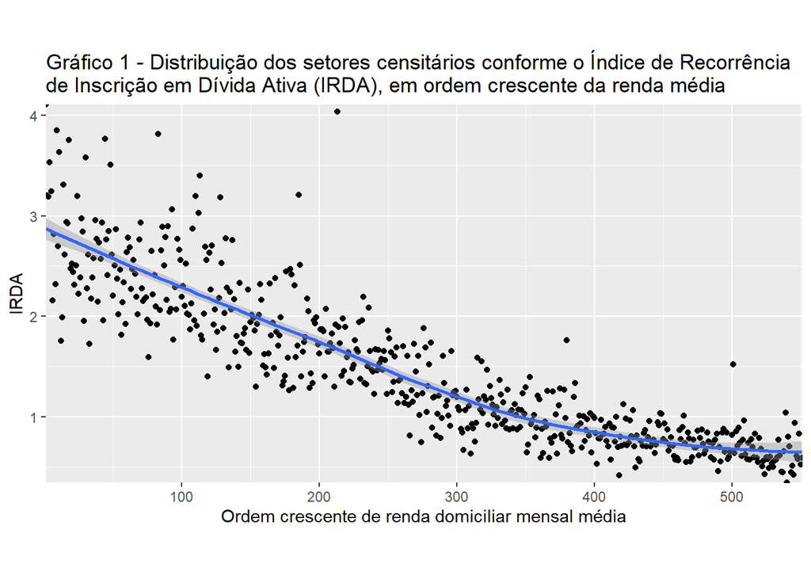

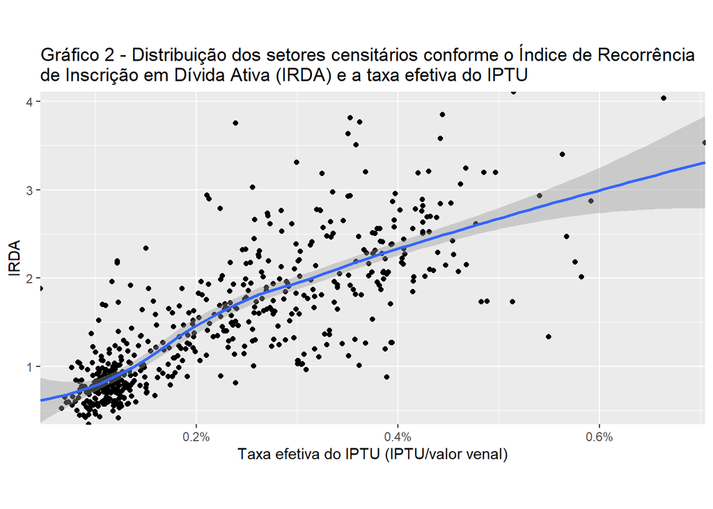

## Perfil do pagamento da dívida ativa

É preciso avaliar agora o que leva o munícipe a pagar a dívida ativa, uma vez que esteja inscrito. Para isso, contrastamos o IRPG com as demais informações disponíveis e percebemos que a presença ou não de CPF ou CNPJ na base da prefeitura possui um elevado poder explicativo (Gráfico 3).

Outro fator que se destacou foi o próprio índice de recorrência de inscrição em dívida ativa (IRDA). A forte correlação negativa entre os dois índices (Gráfico 4) sugere que aqueles inscritos que não possuem histório de inscrição anterior possuem maior probabilidade de pagar a dívida.

O Gráfico 7 sumariza as informações presentes no gráficos 4, 5 e 6 ao apresentar a linha de tendência para o IRPG total (verde), dos domicílios com documento (vermelho) e dos domicílios sem documento (azul). É possível observar que os efeitos de ter o documento cadastrado na prefeitura são mais significativos para os imóveis de maior recorrência de inscrição em dívida ativa.

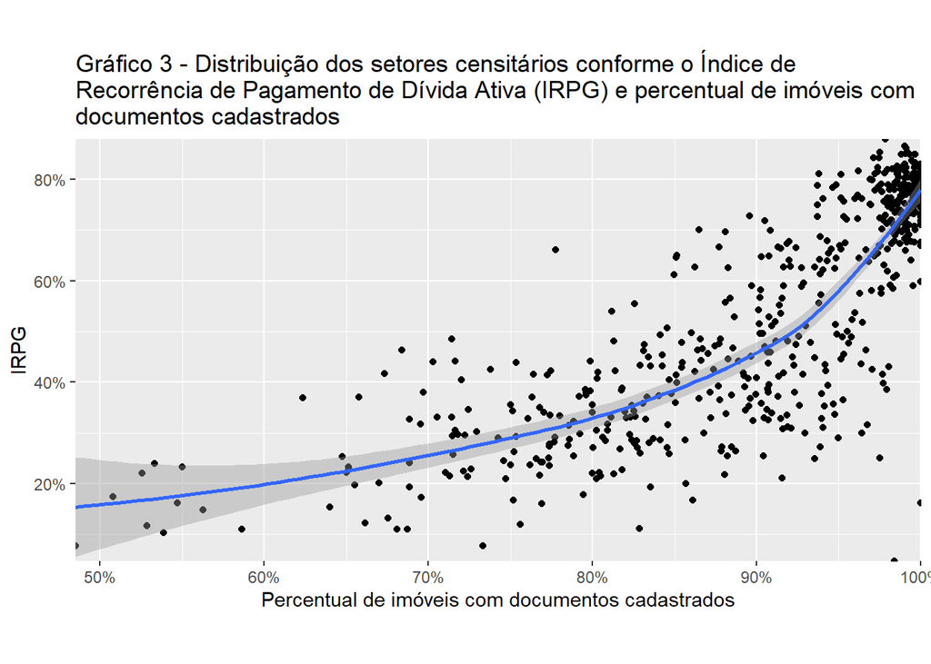

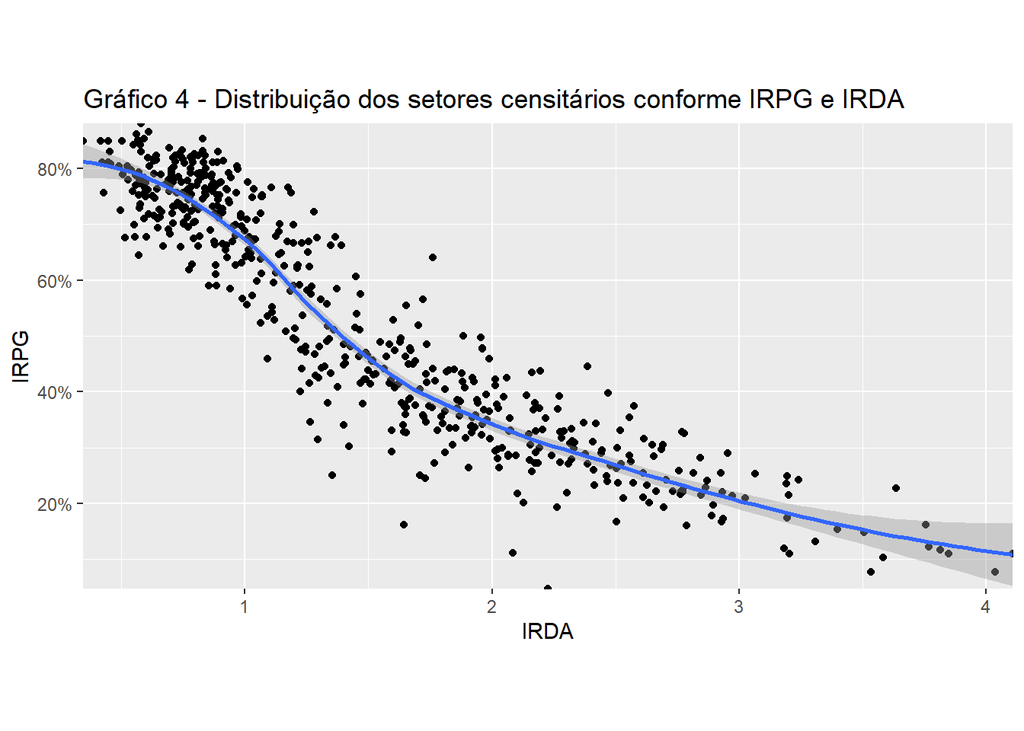

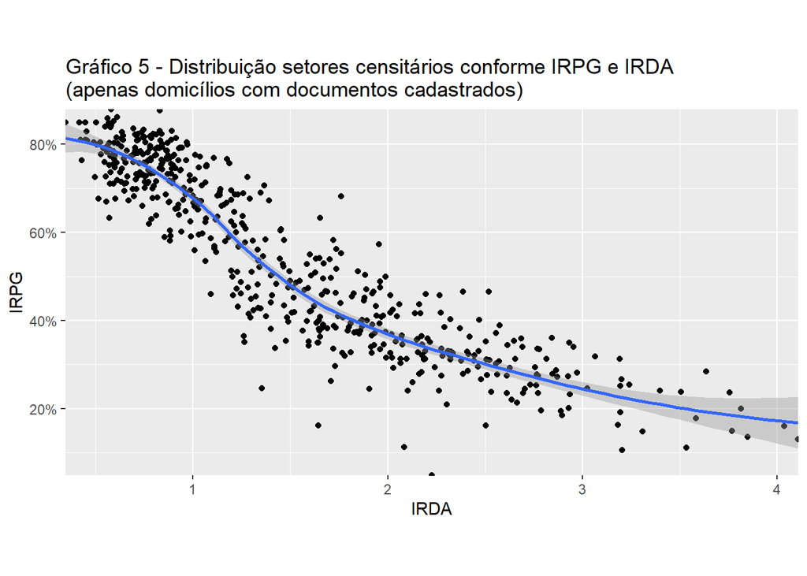

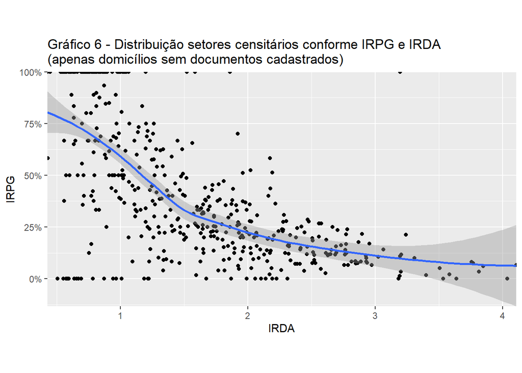

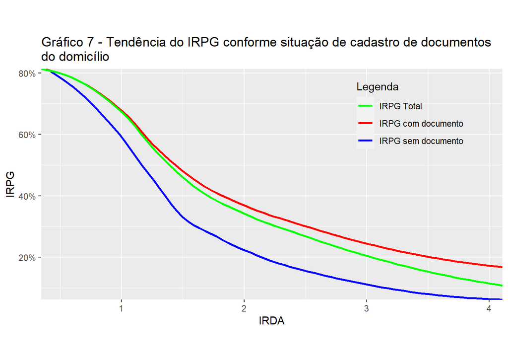

## O efeito de ter documento é mais significativo nos setores de mais baixa renda.

Os Gráficos 8 e 9 mostram o IRPG conforme situação do cadastro do documento nos diversos setores censitários ordenados pelo nível de renda. O Gráfico 8 parecer mostrar que o registro do documento gera um IRPG mais elevado nos setores de mais alta renda (sobretudo os que se encontram acima da 300ª posição). Essa aparência é desfeita com a análise do Gráfico 9 que, além da distribuição do IRPG dos domicílios sem documentos cadastrados, traz também a linha de tendência dos domicílios com documentos cadastrados (do Gráfico 8). A distância entre as duas linhas de tendência é maior para os imóveis abaixo da 300ª posição, indicando que o efeito do cadastro da documentação é mais significativo para os setores com baixo nível de renda domiciliar média.

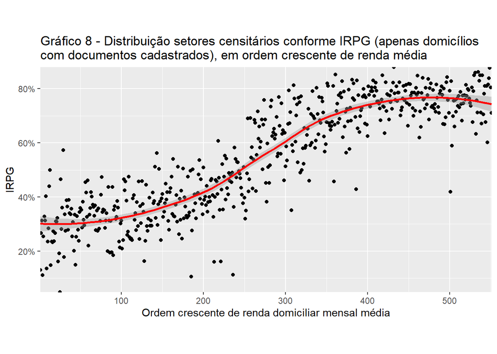

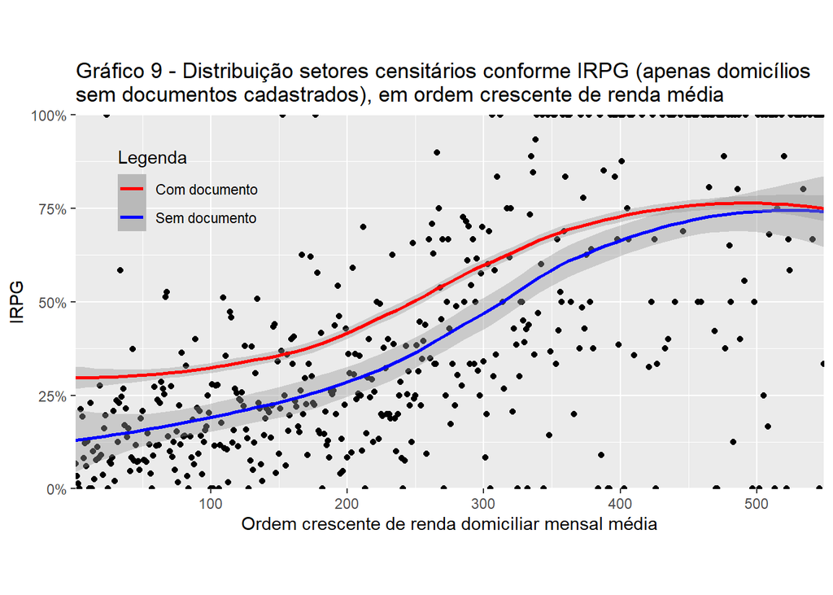

## Linhas de ação sugeridas

Esses dados sugerem dois caminhos de ação.

O primeiro, diz respeito a buscar completar o cadastro da prefeitura, incluindo as informações referentes ao CPF e CNPJ. Os domicílios que possuem documentos cadastrados na base da prefeitura possuem uma probabilidade maior de pagar o IPTU inscrito em dívida ativa (72% contra 60% dos imóveis sem documento). Atualmente, 5.749 dos imóveis inscritos em dívida ativa não possuem documentos cadastrados na base da prefeitura. A dívida ativa total desses imóveis é de R$ 6.087.034,22. Supondo que a complementação do cadastro elevaria os índices de pagamento da dívida ativa aos patamares observados pelo IRPG dos imóveis que atualmente possuem essas informações (Gráfico 5), é possível concluir que uma **ação desse tipo poderia promover a recuperação de R$1.317.699,76**. Essa possibilidade de recuperação teria mais efeito sobre os residentes dos setores censitário de mais baixa renda (Gráfico 10).

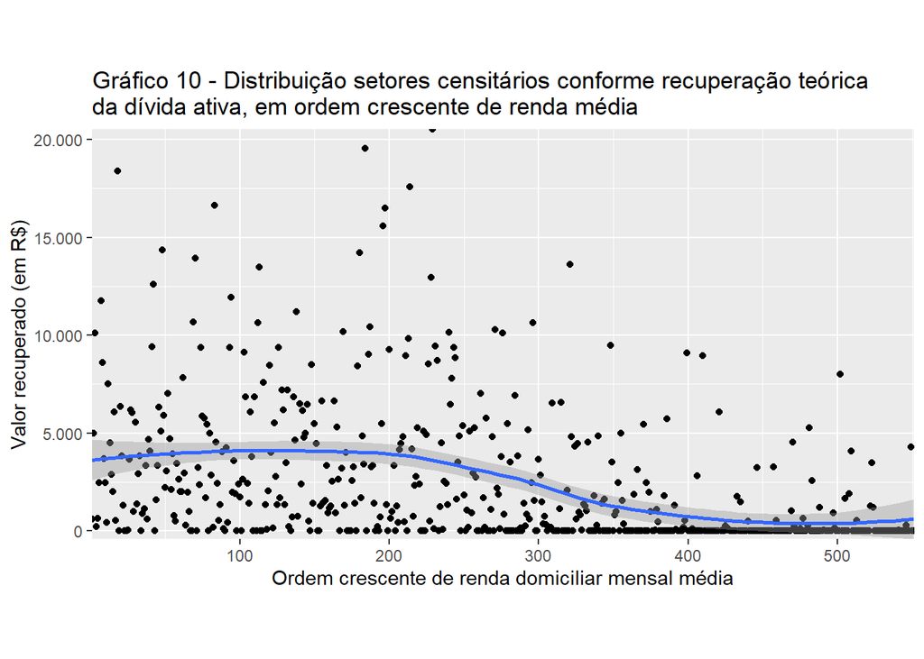

Tabela 1 - Índices de pagamento conforme recorrência de inscrição na dívida ativa

| Número de inscrições | Probabilidade de pagamento |
| --- | --- |
| 1 | 74% |
| 2 | 66% |
| 3 | 54% |
| 4 | 38% |
| 5 | 10% |

Uma segunda linha de ação consistiria em incluir um processo de cobrança pró-ativa que busque evitar que o munícipe seja inscrito na Dívida Ativa. Ao observar o IRPG conforme recorrência de inscrição, podemos ver que os índices de pagamento reduzem significativamente após a segunda reincidência (Tabela 1).

Aqueles munícipes que não possuem histórico de inscrição ou que foram inscritos apenas uma vez em dívida ativa possuem alta probabilidade de pagarem suas dívidas. Atualmente, existem 11.349 que se enquandram nessa situação, de um total de 40.508 domicílios com IPTU em atraso no exercício corrente.

**O envio de uma mensagem informando sobre o débito em aberto e alertando para as consequências da inscrição me dívida ativa poderia evitar a inscrição de algo entre 66% a 74% do valor desse IPTU em atraso, o que representaria um montante em torno de R$ 1.836.021,64** .